# NORDIS report data exploration

Arto Kekkonen

2023-10-06

# Introduction

Here, we start working on the report, based on the TOC. As the report is in English, I’ll write this in English as well.

Right now, this covers simple explorations of questions 1 and 2.

Some things to note:

- Weighted counts are NOT rounded to the nearest integer. This means that if we were to create a table of, say, how many respondents picked option 1 for question 1, it could say something like “408.5”.
- There’s no guarantee that proportions add up to 100!

Both of these can be fixed by rounding at some point, preferrably just before a table/figure that’s shown is generated. Let me know if this is an issue.

At this point, all tables and figures use labels from the Finnish data set. If you can give me a list of preferred labels to use for the English version, I can modify these so that they’re used.

The first to go is question 1. Let’s check that out.

```r
data <- read_sav("/home/arto/Data/mediatrust/Combined.sav")
```

```r
data_sel <- data #%>%
  #dplyr::select(country, uuid_no, uuid_se, uuid_de, uuid_fi, age, age_group, gender, gender_fi, Q15_no, Q15_se, Q15_de, Q15_fi, uuid_fi, weight, starts_with("Q1_"))
```

```r
data_swe <- data_sel %>% dplyr::filter(country == 1)
data_den <- data_sel %>% dplyr::filter(country == 2)
data_nor <- data_sel %>% dplyr::filter(country == 3)
data_fin <- data_sel %>% dplyr::filter(country == 4)

svy_swe <- svydesign(ids = ~uuid_se, weights = ~weight, data = data_sel %>% dplyr::filter(country == 1))
svy_den <- svydesign(ids = ~uuid_de, weights = ~weight, data = data_sel %>% dplyr::filter(country == 2))
svy_nor <- svydesign(ids = ~uuid_no, weights = ~weight, data = data_sel %>% dplyr::filter(country == 3))
svy_fin <- svydesign(ids = ~uuid_fi, weights = ~weight, data = data_sel %>% dplyr::filter(country == 4))

total_swe <- 1025
total_den <- 1000
total_nor <- 1045
total_fin <- 1093
```

# Q2 Most important news sources and Q1 Frequency of following media and online services

```r
labels_for_media <- function(x) {

  #label <- get_label(data[c(x)])
  #label <- x

  #label_two <- str_match(label, "(?:-)(.+)")[,2]
  #label_two <- x

  return(str_match(x, "(?:-)(.+)")[,2])

  #return(label_two)
}
```

```r
# q1_var_labels <- sjlabelled::get_label(data_sel %>% dplyr::select(starts_with("Q1_")))
#
# data_sel %>%
#  dplyr::select(starts_with("Q1_")) %>%
#  dplyr::rename(all_of(setNames(names(q1_var_labels), q1_var_labels))) %>%
#  dplyr::mutate(across(everything(), ~ as_label(.x)))

q1_labels <- c("Useita kertoja päivässä" = "1",
               "Noin kerran päivässä" = "2",
               "Muutaman kerran viikossa" = "3",
               "Noin kerran viikossa" = "4",
               "Muutaman kerran kuussa" = "5",
               "Harvemmin" = "6",
               "En lainkaan" = "7")

q2_labels <- c("No" = "0",
               "Yes" = "1")

q1_levels <- rev(names(q1_labels))
colors <- c("#005B9A", "#9AC2FF", "#C5C4C4", "#F49595", "#F20606")
```

## Sweden

### News sources

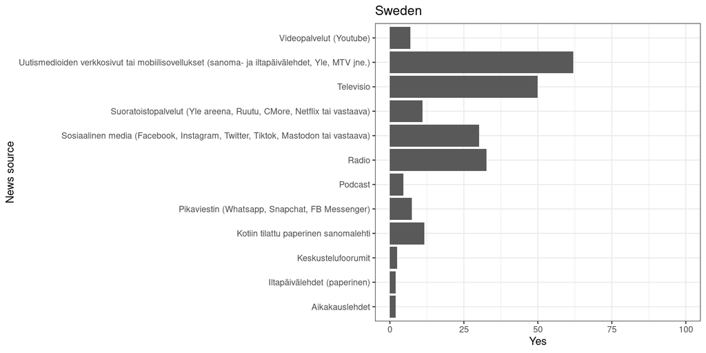

```r
q2_tableframe_swe <- summarize_q(data_swe, "Q2", c(1:12), svy_swe, total_swe, q2_labels, 2) %>%
  dplyr::mutate(Kysymys = labels_for_media(Kysymys)) %>%
  dplyr::rename(`News source` = Kysymys) %>%
  dplyr::select(-Keskiarvo)

p2_swe <- q2_tableframe_swe %>%
  ggplot(aes(x = `News source`, y = Yes)) +
    geom_bar(stat = "identity") +
    lims(y = c(0, 100)) +
    coord_flip() +
    ggtitle("Sweden")

p2_swe
```

```r
kable(q2_tableframe_swe, booktabs = TRUE) %>%
  kable_styling(bootstrap_options = c("striped", "hover", "condensed"))
```

| News source | No | Yes |
| --- | --- | --- |
| Televisio | 50.1 | 49.9 |
| Radio | 67.4 | 32.6 |
| Kotiin tilattu paperinen sanomalehti | 88.4 | 11.6 |
| Iltapäivälehdet (paperinen) | 98.0 | 2.0 |
| Aikakauslehdet | 98.0 | 2.0 |
| Uutismedioiden verkkosivut tai mobiilisovellukset (sanoma- ja iltapäivälehdet, Yle, MTV jne.) | 38.1 | 61.9 |
| Suoratoistopalvelut (Yle areena, Ruutu, CMore, Netflix tai vastaava) | 89.0 | 11.0 |
| Sosiaalinen media (Facebook, Instagram, Twitter, Tiktok, Mastodon tai vastaava) | 69.8 | 30.2 |
| Videopalvelut (Youtube) | 93.1 | 6.9 |
| Podcast | 95.5 | 4.5 |
| Pikaviestin (Whatsapp, Snapchat, FB Messenger) | 92.6 | 7.4 |
| Keskustelufoorumit | 97.6 | 2.4 |

### Frequency of use

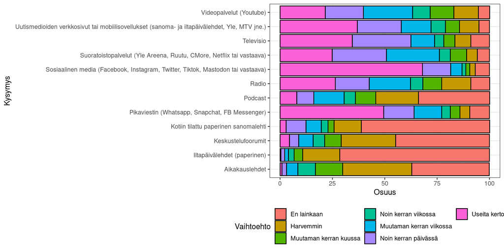

```r
q1_tableframe_swe <- summarize_q(data_swe, "Q1", c(1:12), svy_swe, total_swe, q1_labels, 7)
p1_swe <- plot_proportions(q1_tableframe_swe, q1_levels, 7) + guides(fill = guide_legend(nrow = 3))

p1_swe
```

```r
kable(q1_tableframe_swe, booktabs = TRUE) %>%
  kable_styling(bootstrap_options = c("striped", "hover", "condensed"))
```

| Kysymys | Useita kertoja päivässä | Noin kerran päivässä | Muutaman kerran viikossa | Noin kerran viikossa | Muutaman kerran kuussa | Harvemmin | En lainkaan | Keskiarvo |
| --- | --- | --- | --- | --- | --- | --- | --- | --- |
| Televisio | 34.5 | 28.0 | 11.3 | 4.4 | 5.3 | 7.6 | 8.9 | 2.8 |
| Radio | 26.4 | 16.2 | 19.7 | 5.9 | 9.0 | 13.9 | 9.0 | 3.3 |
| Kotiin tilattu paperinen sanomalehti | 2.9 | 9.5 | 7.3 | 3.2 | 2.9 | 13.0 | 61.3 | 5.8 |
| Iltapäivälehdet (paperinen) | 0.4 | 1.8 | 1.8 | 2.7 | 4.1 | 17.7 | 71.5 | 6.5 |
| Aikakauslehdet | 0.9 | 2.2 | 5.4 | 8.4 | 13.0 | 33.0 | 37.0 | 5.8 |
| Uutismedioiden verkkosivut tai mobiilisovellukset (sanoma- ja iltapäivälehdet, Yle, MTV jne.) | 36.9 | 21.0 | 14.2 | 6.9 | 6.7 | 9.3 | 5.0 | 2.7 |
| Suoratoistopalvelut (Yle Areena, Ruutu, CMore, Netflix tai vastaava) | 24.9 | 25.9 | 25.3 | 5.2 | 7.8 | 5.1 | 5.8 | 2.8 |
| Sosiaalinen media (Facebook, Instagram, Twitter, Tiktok, Mastodon tai vastaava) | 68.0 | 13.5 | 5.4 | 1.8 | 1.9 | 2.6 | 6.8 | 1.9 |
| Videopalvelut (Youtube) | 21.6 | 18.2 | 23.5 | 8.4 | 11.3 | 11.7 | 5.4 | 3.3 |
| Podcast | 8.0 | 8.1 | 14.5 | 5.4 | 9.7 | 20.4 | 34.0 | 5.0 |
| Pikaviestin (Whatsapp, Snapchat, FB Messenger) | 49.5 | 14.5 | 13.2 | 4.1 | 4.6 | 4.7 | 9.4 | 2.5 |
| Keskustelufoorumit | 4.5 | 4.4 | 6.9 | 5.5 | 7.9 | 26.0 | 44.8 | 5.7 |

## Denmark

### News sources

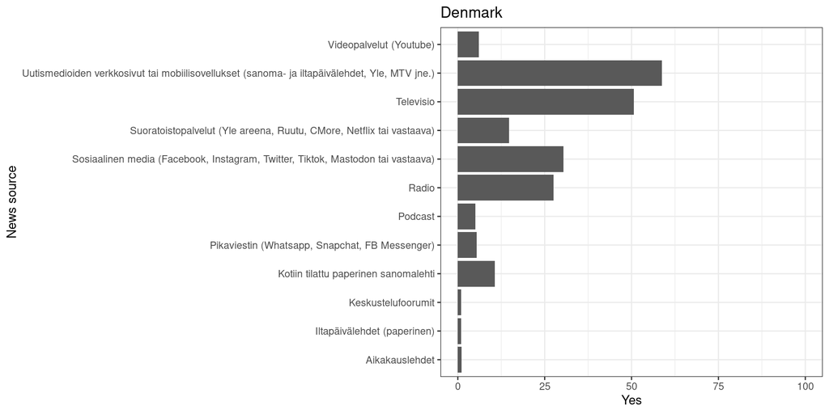

```r
q2_tableframe_den <- summarize_q(data_den, "Q2", c(1:12), svy_den, total_den, q2_labels, 2) %>%
  dplyr::mutate(Kysymys = labels_for_media(Kysymys)) %>%
  dplyr::rename(`News source` = Kysymys) %>%
  dplyr::select(-Keskiarvo)

p2_den <- q2_tableframe_den %>%
  ggplot(aes(x = `News source`, y = Yes)) +
    geom_bar(stat = "identity") +
    lims(y = c(0, 100)) +
    coord_flip() +
    ggtitle("Denmark")

p2_den
```

```r
kable(q2_tableframe_den, booktabs = TRUE) %>%
  kable_styling(bootstrap_options = c("striped", "hover", "condensed"))
```

| News source | No | Yes |
| --- | --- | --- |
| Televisio | 49.3 | 50.7 |
| Radio | 72.5 | 27.5 |
| Kotiin tilattu paperinen sanomalehti | 89.3 | 10.7 |
| Iltapäivälehdet (paperinen) | 99.0 | 1.0 |
| Aikakauslehdet | 98.9 | 1.1 |
| Uutismedioiden verkkosivut tai mobiilisovellukset (sanoma- ja iltapäivälehdet, Yle, MTV jne.) | 41.3 | 58.7 |
| Suoratoistopalvelut (Yle areena, Ruutu, CMore, Netflix tai vastaava) | 85.2 | 14.8 |
| Sosiaalinen media (Facebook, Instagram, Twitter, Tiktok, Mastodon tai vastaava) | 69.6 | 30.4 |
| Videopalvelut (Youtube) | 94.0 | 6.0 |
| Podcast | 95.0 | 5.0 |
| Pikaviestin (Whatsapp, Snapchat, FB Messenger) | 94.6 | 5.4 |
| Keskustelufoorumit | 99.0 | 1.0 |

### Frequency of use

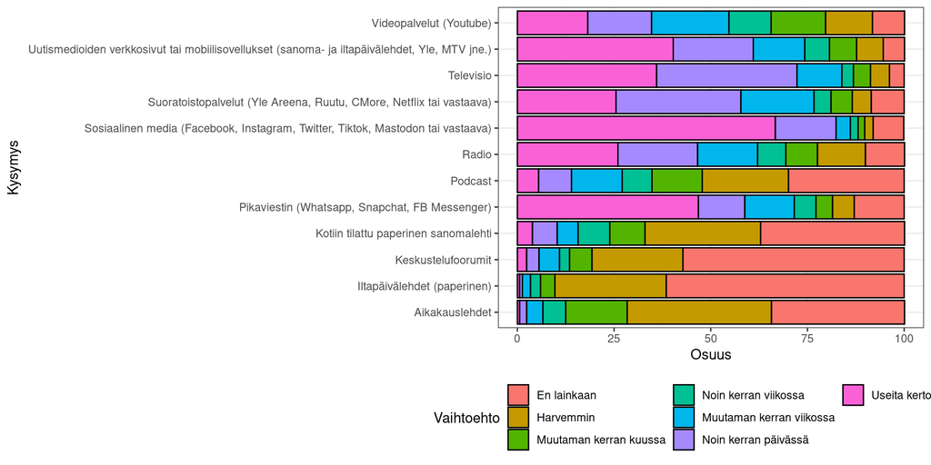

```r
q1_tableframe_den <- summarize_q(data_den, "Q1", c(1:12), svy_den, total_den, q1_labels, 7)
p1_den <- plot_proportions(q1_tableframe_den, q1_levels, 7) + guides(fill = guide_legend(nrow = 3))

p1_den
```

```r
kable(q1_tableframe_den, booktabs = TRUE) %>%
  kable_styling(bootstrap_options = c("striped", "hover", "condensed"))
```

| Kysymys | Useita kertoja päivässä | Noin kerran päivässä | Muutaman kerran viikossa | Noin kerran viikossa | Muutaman kerran kuussa | Harvemmin | En lainkaan | Keskiarvo |
| --- | --- | --- | --- | --- | --- | --- | --- | --- |
| Televisio | 36.0 | 36.3 | 11.6 | 3.0 | 4.4 | 4.9 | 3.8 | 2.3 |
| Radio | 26.0 | 20.6 | 15.5 | 7.3 | 8.2 | 12.4 | 10.1 | 3.3 |
| Kotiin tilattu paperinen sanomalehti | 3.9 | 6.4 | 5.4 | 8.2 | 9.1 | 29.9 | 37.2 | 5.5 |
| Iltapäivälehdet (paperinen) | 0.6 | 0.7 | 2.1 | 2.6 | 3.7 | 28.8 | 61.5 | 6.4 |
| Aikakauslehdet | 0.6 | 1.8 | 4.2 | 5.9 | 15.9 | 37.3 | 34.4 | 5.8 |
| Uutismedioiden verkkosivut tai mobiilisovellukset (sanoma- ja iltapäivälehdet, Yle, MTV jne.) | 40.3 | 20.7 | 13.3 | 6.4 | 7.0 | 6.9 | 5.5 | 2.6 |
| Suoratoistopalvelut (Yle Areena, Ruutu, CMore, Netflix tai vastaava) | 25.5 | 32.3 | 18.9 | 4.4 | 5.5 | 4.9 | 8.5 | 2.8 |
| Sosiaalinen media (Facebook, Instagram, Twitter, Tiktok, Mastodon tai vastaava) | 66.7 | 15.7 | 3.7 | 2.0 | 1.7 | 2.2 | 7.9 | 1.9 |
| Videopalvelut (Youtube) | 18.2 | 16.5 | 20.0 | 10.9 | 14.1 | 12.1 | 8.3 | 3.6 |
| Podcast | 5.5 | 8.5 | 13.1 | 7.7 | 13.0 | 22.3 | 29.9 | 5.0 |
| Pikaviestin (Whatsapp, Snapchat, FB Messenger) | 46.8 | 12.0 | 12.8 | 5.6 | 4.3 | 5.6 | 12.9 | 2.8 |
| Keskustelufoorumit | 2.4 | 3.2 | 5.3 | 2.6 | 5.8 | 23.5 | 57.2 | 6.1 |

## Norway

### News sources

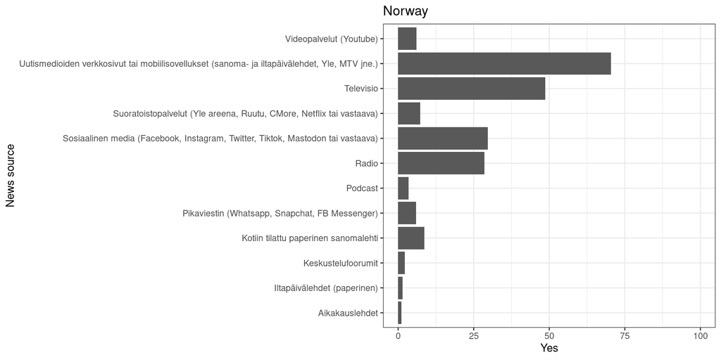

```r
q2_tableframe_nor <- summarize_q(data_nor, "Q2", c(1:12), svy_nor, total_nor, q2_labels, 2) %>%
  dplyr::mutate(Kysymys = labels_for_media(Kysymys)) %>%
  dplyr::rename(`News source` = Kysymys) %>%
  dplyr::select(-Keskiarvo)

p2_nor <- q2_tableframe_nor %>%
  ggplot(aes(x = `News source`, y = Yes)) +
    geom_bar(stat = "identity") +
    lims(y = c(0, 100)) +
    coord_flip() +
    ggtitle("Norway")

p2_nor
```

```r
kable(q2_tableframe_nor, booktabs = TRUE) %>%
  kable_styling(bootstrap_options = c("striped", "hover", "condensed"))
```

| News source | No | Yes |
| --- | --- | --- |
| Televisio | 51.3 | 48.7 |
| Radio | 71.4 | 28.6 |
| Kotiin tilattu paperinen sanomalehti | 91.3 | 8.7 |
| Iltapäivälehdet (paperinen) | 98.5 | 1.5 |
| Aikakauslehdet | 98.9 | 1.1 |
| Uutismedioiden verkkosivut tai mobiilisovellukset (sanoma- ja iltapäivälehdet, Yle, MTV jne.) | 29.6 | 70.4 |
| Suoratoistopalvelut (Yle areena, Ruutu, CMore, Netflix tai vastaava) | 92.7 | 7.3 |
| Sosiaalinen media (Facebook, Instagram, Twitter, Tiktok, Mastodon tai vastaava) | 70.4 | 29.6 |
| Videopalvelut (Youtube) | 94.0 | 6.0 |
| Podcast | 96.5 | 3.5 |
| Pikaviestin (Whatsapp, Snapchat, FB Messenger) | 94.1 | 5.9 |
| Keskustelufoorumit | 97.8 | 2.2 |

### Frequency of use

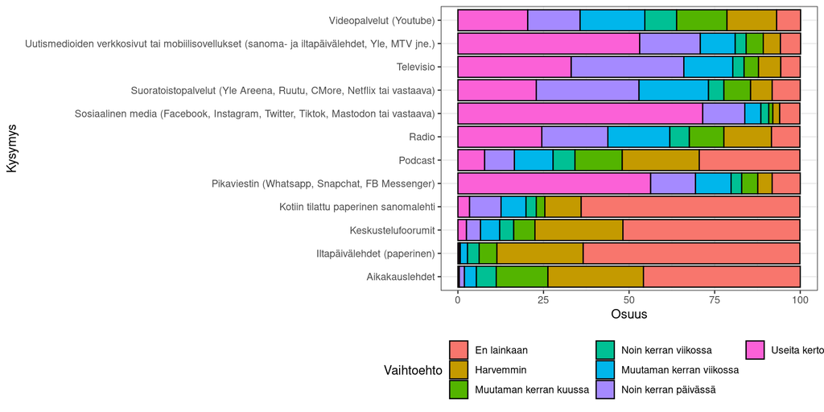

```r
q1_tableframe_nor <- summarize_q(data_nor, "Q1", c(1:12), svy_nor, total_nor, q1_labels, 7)
p1_nor <- plot_proportions(q1_tableframe_nor, q1_levels, 7) + guides(fill = guide_legend(nrow = 3))

p1_nor
```

```r
kable(q1_tableframe_nor, booktabs = TRUE) %>%
  kable_styling(bootstrap_options = c("striped", "hover", "condensed"))
```

| Kysymys | Useita kertoja päivässä | Noin kerran päivässä | Muutaman kerran viikossa | Noin kerran viikossa | Muutaman kerran kuussa | Harvemmin | En lainkaan | Keskiarvo |
| --- | --- | --- | --- | --- | --- | --- | --- | --- |
| Televisio | 33.1 | 32.9 | 14.3 | 3.3 | 4.2 | 6.5 | 5.7 | 2.5 |
| Radio | 24.5 | 19.3 | 18.1 | 5.7 | 10.1 | 13.9 | 8.3 | 3.3 |
| Kotiin tilattu paperinen sanomalehti | 3.4 | 9.2 | 7.3 | 3.0 | 2.5 | 10.6 | 63.9 | 5.8 |
| Iltapäivälehdet (paperinen) | 0.4 | 0.3 | 2.1 | 3.4 | 5.2 | 25.2 | 63.3 | 6.4 |
| Aikakauslehdet | 0.4 | 1.5 | 3.5 | 5.8 | 15.1 | 27.9 | 45.8 | 6.0 |
| Uutismedioiden verkkosivut tai mobiilisovellukset (sanoma- ja iltapäivälehdet, Yle, MTV jne.) | 53.1 | 17.7 | 10.2 | 3.2 | 5.0 | 5.0 | 5.9 | 2.3 |
| Suoratoistopalvelut (Yle Areena, Ruutu, CMore, Netflix tai vastaava) | 22.9 | 30.0 | 20.3 | 4.5 | 7.8 | 6.3 | 8.2 | 3.0 |
| Sosiaalinen media (Facebook, Instagram, Twitter, Tiktok, Mastodon tai vastaava) | 71.5 | 12.3 | 4.7 | 2.3 | 1.2 | 2.0 | 5.9 | 1.8 |
| Videopalvelut (Youtube) | 20.4 | 15.3 | 18.9 | 9.3 | 14.7 | 14.5 | 7.0 | 3.5 |
| Podcast | 7.8 | 8.7 | 11.3 | 6.4 | 13.8 | 22.5 | 29.4 | 4.9 |
| Pikaviestin (Whatsapp, Snapchat, FB Messenger) | 56.3 | 13.1 | 10.4 | 3.1 | 4.7 | 4.2 | 8.2 | 2.3 |
| Keskustelufoorumit | 2.5 | 4.1 | 5.6 | 4.1 | 6.2 | 25.7 | 51.7 | 5.9 |

## Finland

### News sources

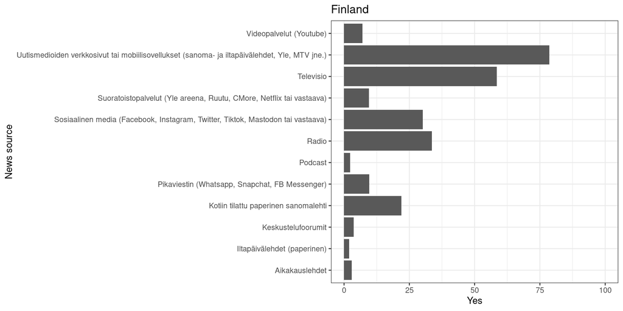

```r
q2_tableframe_fin <- summarize_q(data_fin, "Q2", c(1:12), svy_fin, total_fin, q2_labels, 2) %>%
  dplyr::mutate(Kysymys = labels_for_media(Kysymys)) %>%
  dplyr::rename(`News source` = Kysymys) %>%
  dplyr::select(-Keskiarvo)

p2_fin <- q2_tableframe_fin %>%
  ggplot(aes(x = `News source`, y = Yes)) +
    geom_bar(stat = "identity") +
    lims(y = c(0, 100)) +
    coord_flip() +
    ggtitle("Finland")

p2_fin
```

```r
kable(q2_tableframe_fin, booktabs = TRUE) %>%
  kable_styling(bootstrap_options = c("striped", "hover", "condensed"))
```

| News source | No | Yes |
| --- | --- | --- |
| Televisio | 41.5 | 58.5 |
| Radio | 66.4 | 33.6 |
| Kotiin tilattu paperinen sanomalehti | 78.0 | 22.0 |
| Iltapäivälehdet (paperinen) | 98.1 | 1.9 |
| Aikakauslehdet | 97.1 | 2.9 |
| Uutismedioiden verkkosivut tai mobiilisovellukset (sanoma- ja iltapäivälehdet, Yle, MTV jne.) | 21.4 | 78.6 |
| Suoratoistopalvelut (Yle areena, Ruutu, CMore, Netflix tai vastaava) | 90.5 | 9.5 |
| Sosiaalinen media (Facebook, Instagram, Twitter, Tiktok, Mastodon tai vastaava) | 69.8 | 30.2 |
| Videopalvelut (Youtube) | 93.0 | 7.0 |
| Podcast | 97.7 | 2.3 |
| Pikaviestin (Whatsapp, Snapchat, FB Messenger) | 90.4 | 9.6 |
| Keskustelufoorumit | 96.3 | 3.7 |

### Frequency of use

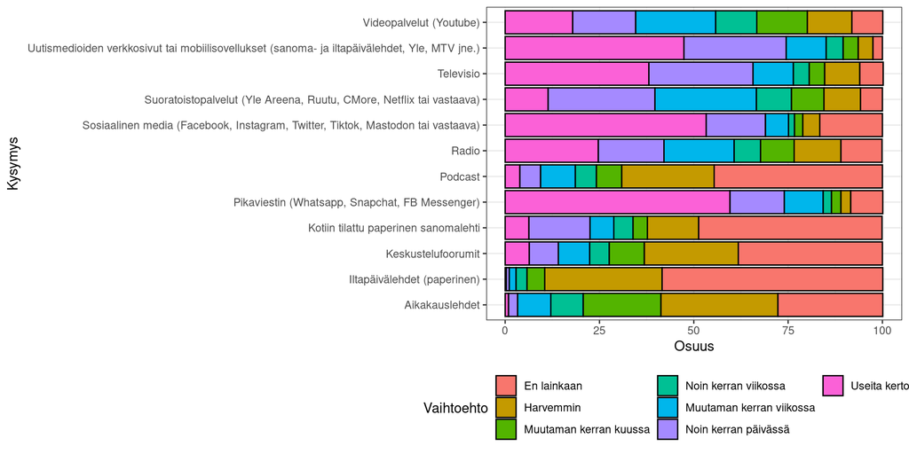

```r
q1_tableframe_fin <- summarize_q(data_fin, "Q1", c(1:12), svy_fin, total_fin, q1_labels, 7)
p1_fin <- plot_proportions(q1_tableframe_fin, q1_levels, 7) + guides(fill = guide_legend(nrow = 3))

p1_fin
```

```r
kable(q1_tableframe_fin, booktabs = TRUE) %>%
  kable_styling(bootstrap_options = c("striped", "hover", "condensed"))
```

| Kysymys | Useita kertoja päivässä | Noin kerran päivässä | Muutaman kerran viikossa | Noin kerran viikossa | Muutaman kerran kuussa | Harvemmin | En lainkaan | Keskiarvo |
| --- | --- | --- | --- | --- | --- | --- | --- | --- |
| Televisio | 38.1 | 27.6 | 10.7 | 4.2 | 4.1 | 9.3 | 6.2 | 2.6 |
| Radio | 24.7 | 17.4 | 18.6 | 7.0 | 8.9 | 12.4 | 10.9 | 3.4 |
| Kotiin tilattu paperinen sanomalehti | 6.3 | 16.2 | 6.3 | 5.1 | 3.8 | 13.6 | 48.6 | 5.2 |
| Iltapäivälehdet (paperinen) | 0.3 | 0.8 | 1.8 | 2.9 | 4.7 | 31.1 | 58.5 | 6.4 |
| Aikakauslehdet | 0.9 | 2.4 | 8.8 | 8.6 | 20.6 | 31.0 | 27.8 | 5.5 |
| Uutismedioiden verkkosivut tai mobiilisovellukset (sanoma- ja iltapäivälehdet, Yle, MTV jne.) | 47.4 | 27.1 | 10.6 | 4.5 | 4.0 | 3.9 | 2.5 | 2.1 |
| Suoratoistopalvelut (Yle Areena, Ruutu, CMore, Netflix tai vastaava) | 11.4 | 28.3 | 26.9 | 9.3 | 8.6 | 9.7 | 5.8 | 3.3 |
| Sosiaalinen media (Facebook, Instagram, Twitter, Tiktok, Mastodon tai vastaava) | 53.3 | 15.7 | 6.1 | 1.6 | 2.2 | 4.5 | 16.6 | 2.6 |
| Videopalvelut (Youtube) | 17.9 | 16.7 | 21.2 | 10.9 | 13.4 | 11.8 | 8.2 | 3.5 |
| Podcast | 3.9 | 5.5 | 9.2 | 5.6 | 6.7 | 24.5 | 44.6 | 5.6 |
| Pikaviestin (Whatsapp, Snapchat, FB Messenger) | 59.6 | 14.4 | 10.3 | 2.2 | 2.5 | 2.6 | 8.5 | 2.2 |
| Keskustelufoorumit | 6.4 | 7.7 | 8.3 | 5.2 | 9.3 | 24.9 | 38.2 | 5.3 |

## All together

### News sources

The patterns are roughly similar: in all countries, news media websites are the most important news sources, followed by television. Radio and social media are approximately equally important. Paper newspapers are more important for Finns than others.

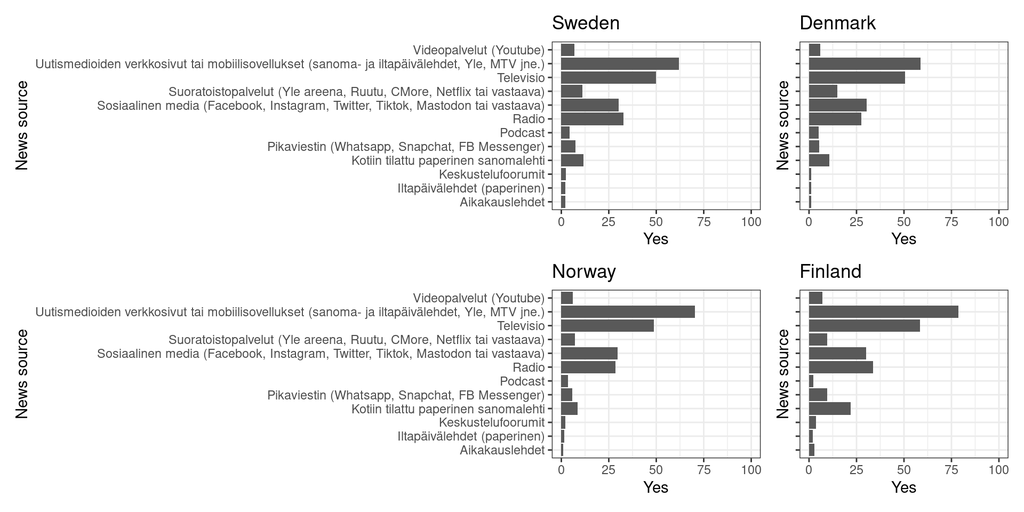

```r
p2_swe + (p2_den + theme(axis.text.y=element_blank())) + p2_nor + (p2_fin + theme(axis.text.y=element_blank())) + plot_layout(guide = "collect") &
  theme(legend.position = "bottom")
```

### Frequency of use

What really surprises me here is that nobody seems to regularly read tabloid newspapers. Then again, Wikipedia says that on average, Iltalehti has ~170 000 readers, which I guess kinda fits with the data here.

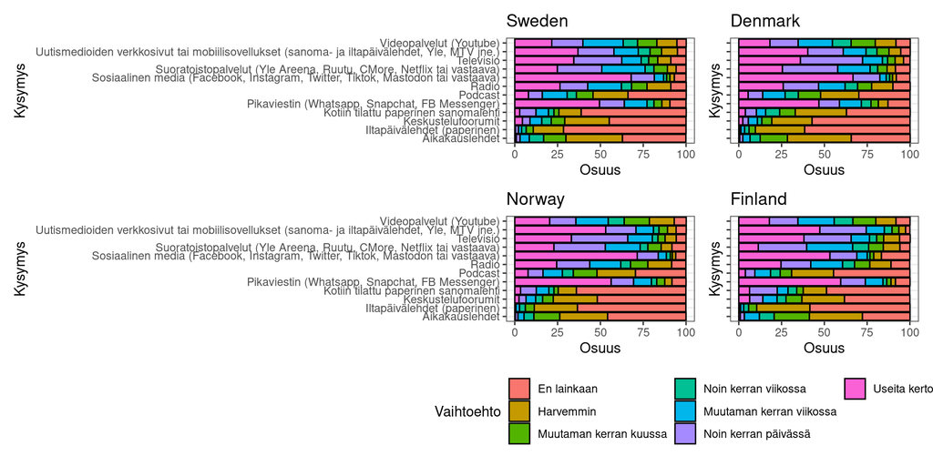

```r
(p1_swe + ggtitle("Sweden")) +
(p1_den + ggtitle("Denmark") + theme(axis.text.y=element_blank())) +
(p1_nor + ggtitle("Norway")) +
(p1_fin + ggtitle("Finland") + theme(axis.text.y=element_blank())) +
  plot_layout(guide = "collect") &
  theme(legend.position = "bottom")
```